# Alderspensjon

Kapittel 7 i Barr

Mikko Moilanen

2026-04-10

## Introduksjon

## Økonomisk bærekraft av pensjonssystemet i Norge

Bærekraft handler om at pensjonssystemet kan finansieres over tid uten store kutt eller skatteøkninger.

- økonomisk bærekraft er en hovedprioritet
- gir trygghet for fremtidige pensjoner
- press fra:
  - økt levealder
  - svakere vekst i yrkesaktiv befolkning
- stabil utgiftsutvikling er avgjørende
- levealdersjustering demper utgiftspresset
- høyere yrkesdeltakelse styrker finansieringen

## Demografi og økonomiske utfordringer

- færre yrkesaktive per pensjonist → svakere finansieringsgrunnlag
- økt levealder → flere år med pensjonsutbetalinger
- ⇒ behov for tilpasninger for å opprettholde bærekraft

## Flere eldre vil legge press på offentlige finanser

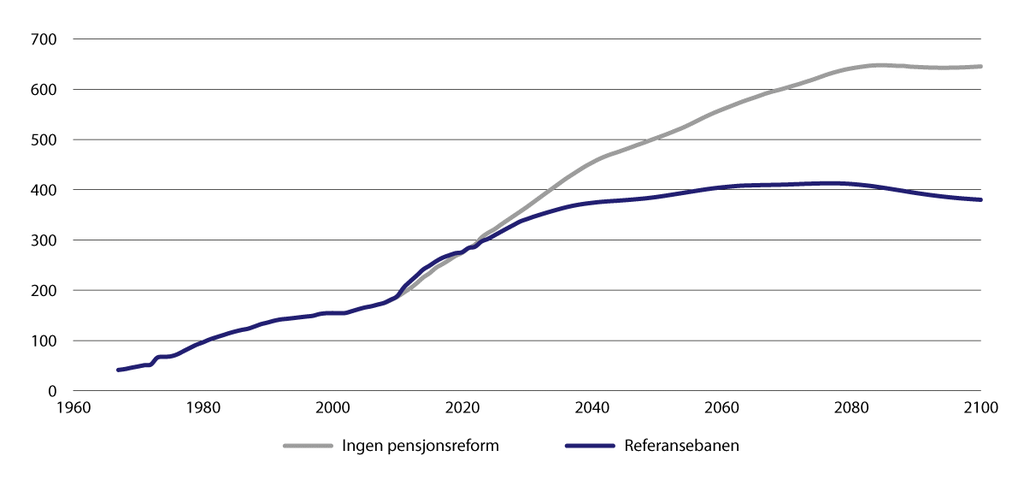

Utgifter til alderspensjon fra folketrygden. Mrd. 2023-kroner (lønnsdeflatert). Framskrevet etter 2022 Kilde: Statistisk sentralbyrå

## Endringer i befolkningssammensetning fører til økt forsørgelsesbyrde

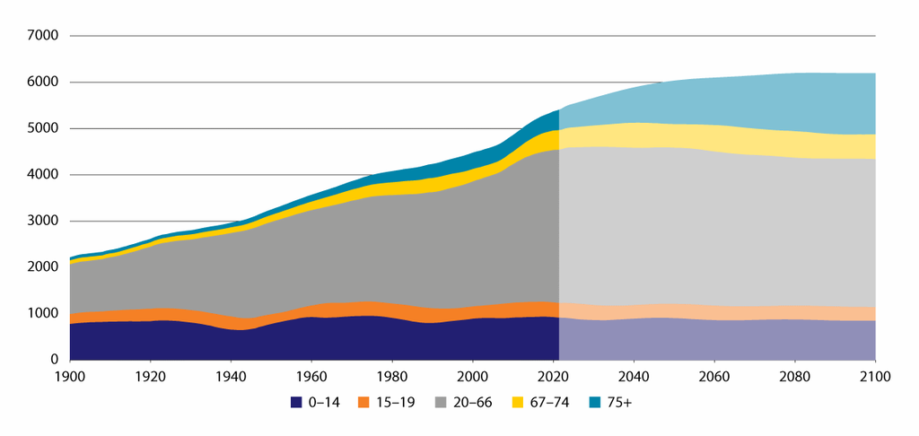

Befolkning fordelt på aldersgrupper 1900 til 2100 i 1000 personer. Registrert og middelalternativet i befolkningsframskrivingene fra 2022 (BF2022). Kilde: Statistisk sentralbyrå

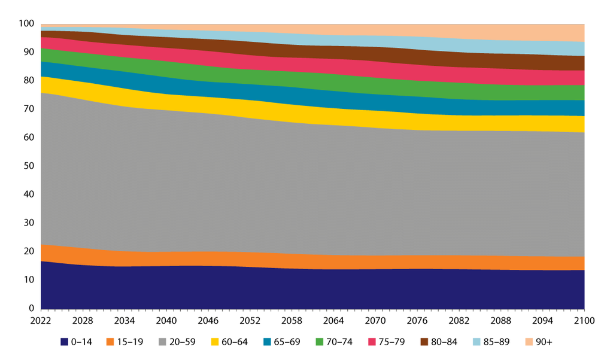

Prosentandel av befolkningen etter aldersgrupper, framskrevne tall middelalternativet i befolkningsframskrivingene fra 2022. Kilde: Statistisk sentralbyrå

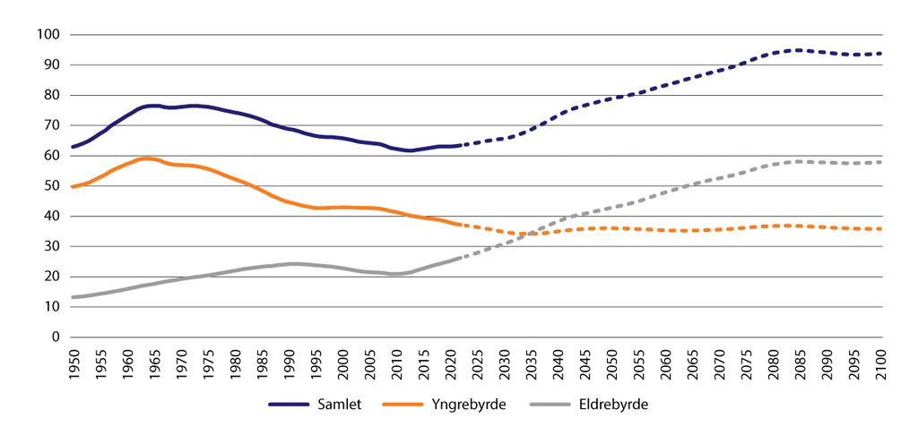

Utviklingen i samlet forsørgelsesbyrde 1950–2100. Prosent. Historiske tall 1950–2022. Framskriving 2023–2100 fra middelalternativet i befolkningsframskrivingen 2022.Kilde: Statistisk sentralbyrå.

## Pensjonenes hovedmål

- konsumglatting
  - individer maksimerer sin nytte over tid, ikke bare på ett tidspunkt
  - pensjoner gjør det mulig å overføre forbruk fra de produktive midtårene til pensjonistårene
  - gir ønsket forbruksprofil over tid

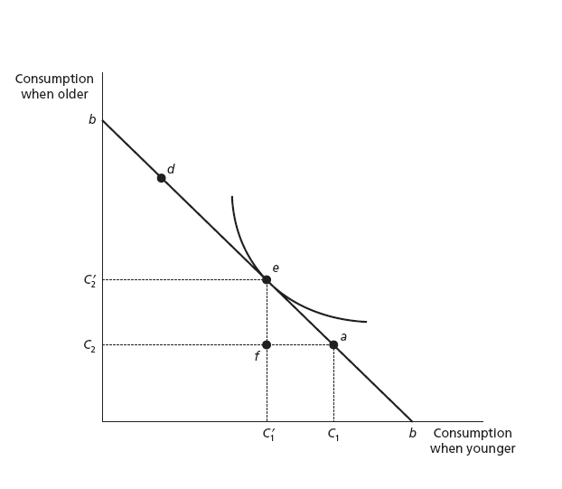

- forsikring
  - levealder er usikker
  - uten forsikring kan individer enten spare for lite eller for mye
- hvorfor statlig inngrep?:
  - markedssvikt i private løsninger
  - rettferdighetshensyn
    - fattigdomsbekjempelse og omfordeling

### Sekundære mål

- **økonomisk vekst**
  - pensjonssystemet påvirker insentiver i økonomien
  - dårlig utforming kan:
    - redusere arbeidstilbud (tidligpensjonering, svake insentiver)
    - fortrenge privat sparing
  - godt utformede systemer kan:
    - øke yrkesdeltakelse og pensjoneringsalder
    - bidra til høyere samlet sparing og kapitalakkumulering
    - støtte velfungerende arbeids- og kapitalmarkeder

## Effektivitetsargumenter for statlig intervensjon

### Mikroøkonomiske aspekter

### Tilbudssiden: Ufullstendig forsikring

- effektiv konsumglatting krever at enkeltpersoner kjøper det sanfunnsøkonomisk optimale nivået av pensjon
  - ville folk bidratt frivillig til en pensjonsordning?
  - hvorfor gjør staten pensjonsinnbetalingen obligatorisk?
  - hvorfor tilbyr myndighetene pensjoner?

#### Ville folk bidratt frivillig til en pensjonsordning?

- i en verden med perfekt informasjon og fullstendige markeder:
  - individer kan selv oppnå konsumglatting gjennom frivillig sparing
  - ingen behov for obligatoriske ordninger
- i praksis:
  - usikker levealder skaper behov for forsikring (longevity risk)
  - effektive løsninger krever en kombinasjon av sparing og risikodeling (f.eks. livrenter)
- en rasjonell, risikoavers person vil etterspørre en pensjonsordning dersom:
  $$\text{betalingsvilje for forsikring} \geq \text{nettokostnad}$$

#### Hvorfor gjør staten pensjonsinnbetalingen obligatorisk?

- uten obligatorisk sparing kan individer velge å spare for lite til egen alderdom
- dette skaper **negative eksternaliteter**:
  - kostnadene bæres av fellesskapet (skattebetalerne)

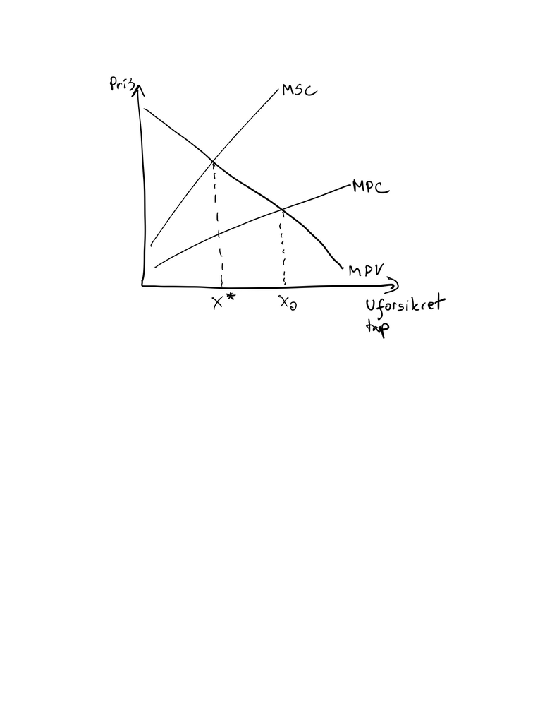

## Hvorfor tilbyr myndighetene pensjoner?

## Tilbudssiden: pensjonsutbetalinger og inflasjon

- på tilbudssiden oppstår to sett med problemer
- er markedene for pensjonsutbetalinger effektive?
- hvordan takler pensjoner inflasjon?
- er forholdene til stede for at det private markedet skal kunne tilby forsikring effektivt?

### Repetisjon: Privat tilbud av forsikring, forutsetninger

$$\pi_i = (1+α) p_iL$$

- de individuelle sannsynlighetene for ulykke/skade ($p_i$) er uavhengig av hverandre (ingen systematisk risiko)
- Må ha usikkerhet, dvs. manglende kunnskap om framtidig utfall $p_i \le 1$
  - om $p_i = 1$, da blir $\pi = (1+α)L > L$
- Risiko, ikke usikkerhet (sannsynlighet må være kjent eller mulig å estimere (forsikringsselskapet må vite gjennomsnittlig $p_i$)
- Ingen asymmetrisk informasjon
  - ingen ugunstig utvalg
  - ingen adferdsrisiko
    - kan påvirke $p_i$ (ex ante -atferdsrisiko)
      - forsikringstakeren kan påvirke sannsynlighet for tap eller størrelse på potensielt tap, gjennom strategisk adferdsendring
      - for eksempel ingen forebygging

## Pensjonsutbetalinger: ville det private markedet kunne tilbudt dem effektivt

- Sannsynligheten for at pensjonist A lever til en gitt alder er uavhengig av pensjonist B ✅
- Risikoen for å leve til en viss alder er mindre enn én ✅
- Den gjennomsnittlige risikoen er kjent ✅
  - dødelighetsdata er lett tilgjengelige
- Ved første øyekast små problemer med uheldig utvalg og moralsk hasard ✅
  - individer kjenner ikke egen dødstid
  - atferd som påvirker utbetaling (f.eks. selvmord) er ikke et klassisk moralsk hasardproblem
- **→ utbetalingsmarkedene ser ut til å oppfylle betingelsene for effektiv forsikring**
  - men dette må nyanseres:
  - systematisk undervurdering av økt levealder
    - flere når pensjonsalder
    - flere år som pensjonist
    - høyere og mer usikre utbetalingsforpliktelser
  - økt usikkerhet om kostnader (“tvilstrakt”)
    - er dødelighet risiko eller genuin usikkerhet?
    - usikkerhet ⇒ uforutsette kostnader
  - i Norden:
    - staten bærer risikoen
    - kostnader deles med skattebetalerne
- **Inflasjon**
  - konsumglatting avhenger av realverdien av pensjon
  - privat inflasjonsforsikring er vanskelig fordi:
    - sannsynlighetsfordelingen for inflasjon er ukjent
    - inflasjon er et felles sjokk
      - perfekt korrelert risiko (ikke diversifiserbar)

## Etterspørselssiden: Informasjons- og atferdsproblemer

- spørsmålet er om individer tar gode pensjonsvalg **dersom alt overlates til private markeder**
- i en først-best økonomi:
  - individet møter et komplett sett av finansielle produkter til konkurransedyktige priser
  - velger optimalt:
    - sparing
    - portefølje
    - fondsforvalter
    - utbetalingsprofil
  - maksimerer livsløpsnytte gitt rammebetingelser

### Informasjonsproblemer

- optimale pensjonsvalg krever at individer forstår:
  - usikkerhet (levealder, avkastning)
  - tilgjengelige markedsalternativer
- i praksis:
  - mange utsetter sparing → for lav eller for sen oppbygging av pensjon
  - skyldes begrenset framsyn, kunnskap og beslutningskapasitet
- typiske informasjonsproblemer:
  - svak forståelse av risiko og fremtidige pensjonsytelser
  - uklarhet om forskjellen mellom ytelses- og innskuddsbaserte ordninger
  - begrenset forståelse av sannsynligheter
  - lav finansiell kompetanse
- fordelingsimplikasjoner:
  - informasjonsfattigdom henger tett sammen med økonomisk fattigdom
  - kan forsterke ulikhet i pensjonsutfall
- **Informasjonsproblemer kan føre til systematisk under-sparing og gi et argument for standardisering, regulering og offentlig involvering**

### Atferdsproblemer

- **begrenset viljestyrke** (“vil ikke”)
  - vet hva som er optimalt, men følger det ikke
  - nåtidspreferanser → kortsiktig tilfredsstillelse dominerer
    - tidsinkonsistens: fremtiden blir alltid “nå”
  - konsekvenser:
    - prokrastinering (utsetter sparing)
    - tidligpensjonering selv om det gir lav levestandard
    - påvirkes av kortsiktige insentiver
    - inertia:
      - automatisk innmelding ⇒ langt høyere deltakelse
- **begrenset rasjonalitet** (“kan ikke”)
  - pensjonsvalg er komplekse (lang horisont, usikkerhet, mange valg)
  - fører til systematiske feil:
    - **framing:** valg påvirkes av presentasjon
    - **kjennskap:** dårlig diversifisering (f.eks. egen arbeidsgiver)
    - **overdreven trading:** høye kostnader, dårlig avkastning
    - **inaktivitet:** gjør ingenting når valgene blir for komplekse
- **implikasjoner for politikk**
  - gir grunnlag for obligatorisk standardsikring
  - men ikke nødvendigvis full offentlig organisering
    - kan også løses via:
      - obligatorisk tjenestepensjon
      - krav om individuell pensjonsforsikring
- **Atferdsproblemer kan gi systematisk undersparing og svake valg, noe som styrker argumentet for obligatoriske pensjonsløsninger**

## Rettfedighetsargumenter for offentlige inngrep

### Offentlig versus privat pensjonsordning

- ligner diskusjonen om rettferdighet i trygdesystemet
- **horisontal rettferdighet** (minstestandarder, like muligheter):
  - kan i teori oppnås uten offentlig inngrep (perfekt informasjon)
  - i praksis: informasjonsproblemer og ulik forhandlingsmakt
  - ⇒ argument for **minimumsstandarder og regulering**
- svak støtte for full offentlig ordning kun basert på rettferdighet alene
- sterkere argument når kombinert med effektivitet:
  - obligatorisk medlemskap reduserer adverse selection
  - felles ordning kan være kostnadseffektiv
- omfordeling:
  - kan begrunnes som et **formyndergode** (paternalistisk motiv)
  - når offentlig drift er effektiv, kan omfordeling skje uten store effektivitetstap

### De omfordelende effektene av pensjoner

- **intergenerasjonell omfordeling**
  - Et PAYG-system (Pay-As-You-Go, dagens arbeidstakere betaler for dagens pensjonister) gjør det mulig for en hel generasjon å motta mer enn summen av sine tidligere bidrag
  - fullt fondssystem (du sparer opp din egen pensjon):
    - ytelser ≈ egne bidrag (lite omfordeling)
  - uventet inflasjon:
    - omfordeling mellom generasjoner (ofte fra gamle til unge)
- **omfordeling fra rik til fattig**
  - progressive pensjonsformler:
    - lav inntekt → relativt høyere pensjon
- **motvirkende mekanismer**
  - høyinntektsgrupper lever lenger → mottar mer over tid
  - lengre utdanning → senere innbetalinger :
    - folk med høyere inntekt har en lengre forventet levealder
    - får derfor pensjon i lengre tid
    - også en tendens til å være lengre i utdanning, og begynner dermed å betale bidrag senere

## Pensjonssystemet i Norge

- dagens norske alderspensjonssystem bygger på et pay-as-you-go-system (PAYG)
  - dagens skatter finansierer dagens pensjonsutbetalinger
  - prinsippet kan føres tilbake til teorien om en overlappende generasjonsmodell (Samuelson, 1958)
    - man går over livsløpet gjennom ulike faser, hvor man er produktiv i arbeidsfør alder og ikke arbeider i siste del av livet
      - man ønsker å konsumere relativt jevnt over hele livsløpet, også som pensjonist
  - teorien viser at det bør inngås en samfunnskontrakt mellom de som er i arbeid og de som er pensjonister ved at det overføres penger fra de sysselsatte til pensjonistene
    - de som er pensjonister i dag, har stått ovenfor den samme kontrakten da de var i arbeid og finansierte pensjonene til de som var pensjonister da
    - de som er i arbeid vil stå overfor den samme samfunnskontrakten når de i fremtiden blir pensjonister.

## Mål og prinsipper for det norske pensjonssystemet

- Hovedmålet er økonomisk og sosial trygghet for alle pensjonister
- Pensjonssystemet skal sikre både grunnsikring (minstepensjon) og standardsikring (pensjon basert på inntekt)
- Pensjonen fungerer som en forsikring mot usikkerhet knyttet til levealder, helse og økonomiske forhold
- Sosial omfordeling er sentralt for å redusere økonomiske forskjeller blant pensjonistene

## Hvorfor trenger vi pensjonsreformer?

- Levealderen øker, mens fødselstallene er lave
- Flere pensjonister må forsørges av hver yrkesaktiv
- Pensjonsutgiftene øker, og bærekraften i pensjonssystemet må ses i sammenheng med bærekraften i offentlige finanser

👉 Klassisk dilemma:

- høyere skatter?
- lavere pensjoner?
- eller flere i arbeid?

## Tre hovedstrategier i europeiske reformer

1. **Lavere pensjonsnivå**
   - lavere erstatningsgrad
   - svakere regulering
   - levealdersjustering
2. **Flere må jobbe lenger**
   - høyere pensjonsalder
   - mindre tidligpensjon
   - sterkere belønning for utsatt avgang
3. **Styrke private / ikke-statlige elementer**
   - tjenestepensjon
   - privat sparing
   - skattefordeler

👉 Norge legger hovedvekten på strategi 2

## Å oppmuntre flere til å jobbe lenger: insentiver til arbeid og utviklingen i yrkesaktiviteten etter Pensjonsreformen 2011

- styrket insentivene til å forbli lengre i arbeidslivet
- Pensjonsopptjening er nå tettere knyttet til arbeidsinntekten hvert år
- Fleksibelt uttak av pensjon gir insentiv til å utsette pensjonsuttaket for å få høyere utbetalinger
- Eldre arbeidstakere har hatt økt yrkesdeltakelse siden forrige reformen i 2011
- Tre viktige elementer påvirker arbeidsinsentiver:
  1. Alleårsopptjening
  2. Fleksibelt uttak av pensjon
  3. Levealdersjustering

## Økonomiske insentiver i folketrygdens alderspensjon

- før reformen i 2011
  - før reformen ga arbeid opptjening til alderspensjon til 70 år
  - opptjening utover 40 år ga normalt ikke økt pensjon
  - arbeidsinntekt ble avkortet mot pensjonen ved tidlig uttak
- etter reformen i 2011:
  - Alleårsopptjening: **opptjening gjennom hele yrkeslivet** (fra 13 til 75 år)
  - Private sektor: AFP ble omgjort til livsvarig tillegg.
  - Offentlig sektor: Vurdering av insentiver for ansatte født før 1963
    - Reformen styrket insentivene til å jobbe lengre
    - Tett sammenheng mellom arbeidsinntekt og pensjonsopptjening
    - Nøytrale uttaksregler stimulerer til senere pensjonering for høyere utbetalinger

## Hvilken type politikk får effekt på arbeidstilbudet blant eldre?

Vi skal bruke [en teoretisk modell fra Hernæs et al. (2016)](https://www-sciencedirect-com.mime.uit.no/science/article/pii/S0047272716300974) til å analysere pensjonsreformen 2011. Vi ser på to mekanismer:

1. **Gjorde arbeid mer attraktivt**
2. **Endret pensjonsalder**

## Modellen

Vi starter med en enkel to-periode modell

- i første periode kan individet fortsatt velge mellom arbeid og fritid
- i andre periode er individet fullt pensjonert:

$$U = u(c_1, l) + u(c_2)$$

med budsjettbetingelse

$$c_1 + c_2 \leq w(1-l) + W + P$$

- $c_1$: konsum i periode 1
- $c_2$: konsum i periode 2
- $l$: fritid i periode 1
- $l_0-l$: arbeid i periode 1
- $w$: lønn
- $W$: likvid privat formue
  - oppsparte midler
  - finansformue
  - annen privat rikdom som kan brukes til konsum
  - høy $W$ gjør det lettere å finansiere konsum uten å jobbe
  - lav $W$ gjør individet mer avhengig av arbeidsinntekt eller pensjon
- $P$: pensjonsformue
  - ikke bare “pensjonen” i snever forstand
  - en oppsummering av:
    - når man kan gå av
    - hvor mye man får
    - hvordan uttakstidspunkt påvirker årlig pensjon
    - hvor generøst systemet er
    - nyttig å tenke $P$ som en funksjon $P = P(R)$, der $R$ er pensjonsalder eller uttakstidspunkt
      - en endring i $P$ kan derfor tolkes som:
        - en endring i pensjonsalderen
        - en endring i reglene for uttak
        - en endring i hvor generøs pensjonen er

## Grafisk framstilling

Vi komprimerer budsjettbetingelsen
$$c = c_1+c_2= w(l_0-l) + W + P$$
Dermed ser vi at :

- helningen av budsjettlinjen er $-w$
- når individet ikke jobber (=har pensjonert seg) i $l=l_0$ er $c=W+P$

Det betyr:

- individet har svake insentiver til å fortsette å jobbe
  1. lav effektiv avkastning av arbeid (fritid er relativt billig)
  2. relativt attraktivt å leve av pensjon og privat formue

👉 individet velger full pensjon ($l = l_0$) og oppnår nyttenivå $U^0$

## Reform: to endringer

$$w \uparrow \quad \text{og} \quad P \downarrow$$

👉 reformen øker nytten

👉 refrmen øker arbeidstilbud (antall arbeidstimer)

## Den indre optimale løsningen er ikke alltid tilgjengelig:

- Å redusere arbeidstid krever:
  - arbeidsgivers samtykke
  - eller ny jobb
  - ofte vanskelig, spesielt for eldre arbeidstakere

👉 Derfor er valget i praksis ofte begrenset til:

- fortsette som før, $l=l^*$
- eller slutte helt, $l=l_0$

👉 individet fortsetter å jobbe

👉 reformen øker også yrkesdeltakelse

## Reformen har to effekter

- Substitusjonseffekt:
  - $w \uparrow$ fritid dyrere 👉 mer attraktivt å jobbe
- Inntektseffekt: $P \downarrow$ mindre inntekt uten arbeid 👉 mer attraktivt å jobbe (antar at fritid er et normalt gode)

## Rolle til $W$

Hvis $W$ er høy:

- individet har høyere arbeidsfri inntekt
- kan lettere velge fritid selv om $P$ faller

Hvis $W$ er lav:

- individet har lavere arbeidsfri inntekt
- individet er mer avhengig av lønn og pensjon
- reagerer sterkere på reformen

## Hvem reagerer mest?

Modellen tilsier at størst reformeffekt kommer for individer som:

- har lav $W$
- er nesten indifferente mellom arbeid og pensjon
- påvirkes sterkt av endringer i både $w$ og $P$

## Utvikling i yrkesaktivitet og avgangsalder etter 2011

- Økt yrkesdeltakelse blant eldre etter reformen
- flere velger å stå lengre i arbeid for å kompensere for levealdersjustering

## Avgangsalderen har økt

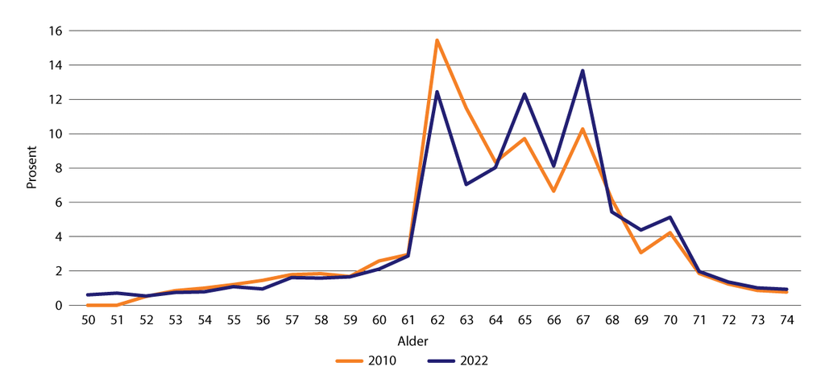

Avgang fra arbeidslivet i 2010 og 2022 etter avgangsalder. Andel i prosent. Kilde: Arbeids- og velferdsdirektoratet.

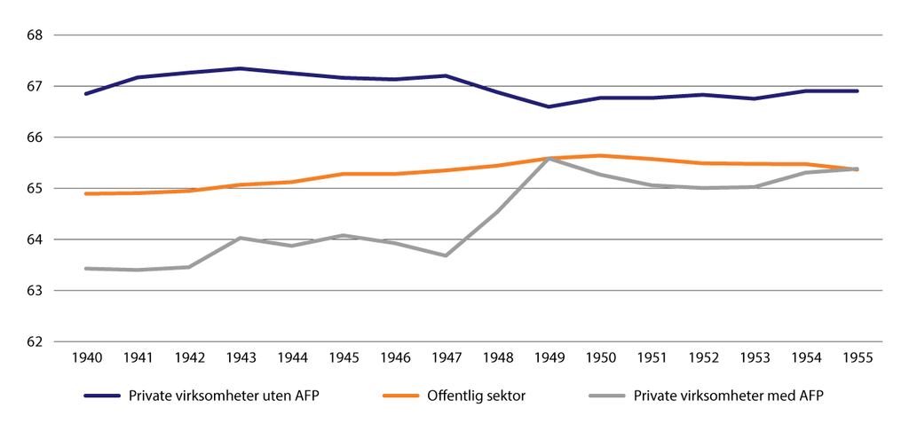

Median avgangsalder blant arbeidsføre etter sektor og fødselsår. Kilde: Arbeids- og velferdsdirektoratet.

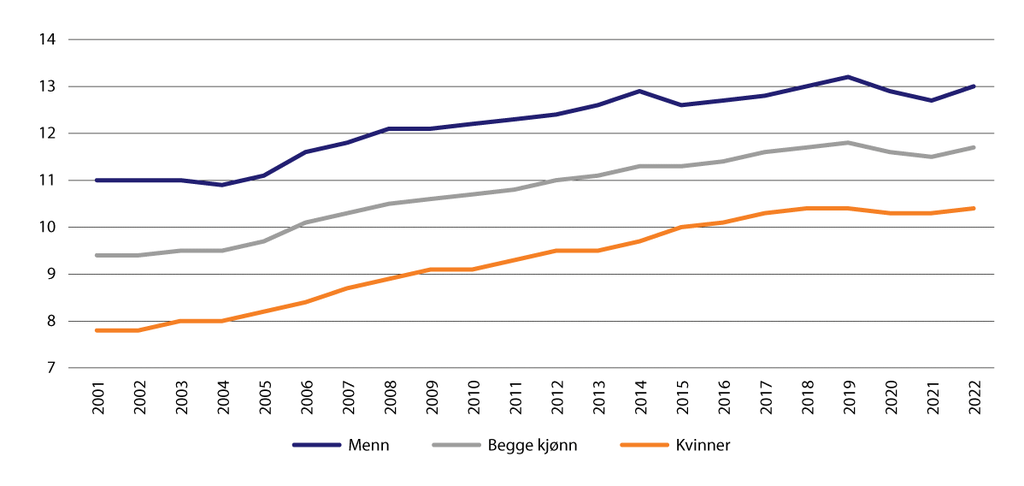

Forventet yrkesaktivitet etter fylte 50 år. Årsverk. Kilde: Arbeids- og velferdsdirektoratet.

## Pensjonsreformen i 2011 har gjort at flere står i jobb lengre

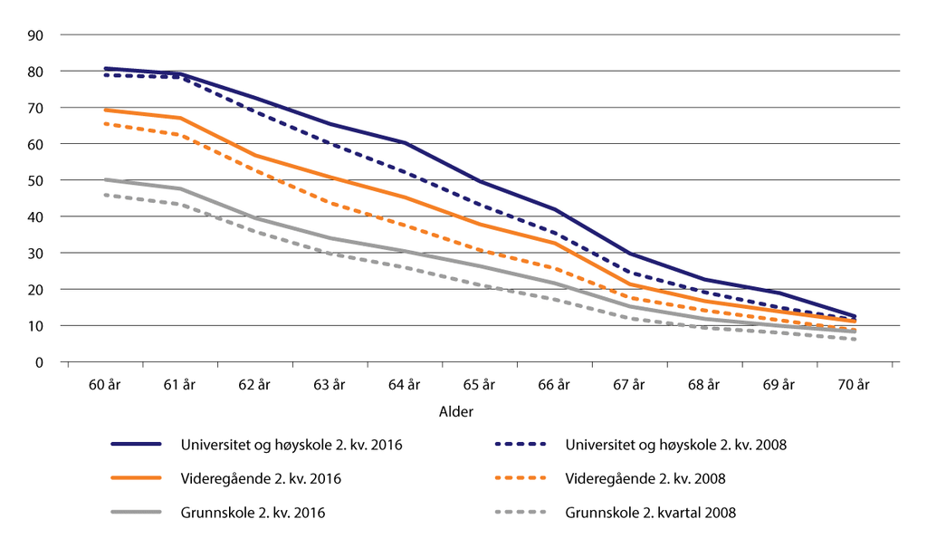

Lønnstakerprosent etter alder og utdanningsnivå for bosatte 60–70 år. Prosent av befolkningen i samme alder 2. kvartal 2008 og 2. kvartal 2016. Kilde: Nordby og Nesheim (2017).

### Andre faktorer som påvirker pensjoneringsbeslutningen

- Faktorer som påvirker når folk velger å pensjonere seg:
  - Trivsel på jobben
  - Helsetilstand
  - Familieforhold og ektefelles pensjonering
  - Arbeidsmarkedssituasjonen for eldre arbeidstakere

## Hovedtrekk i pensjonsforliket 2024

- Pensjonsalderen skal økes i takt med levealderen
  - omtrent ett år per tiår
- Fleksibelt uttak videreføres
- Det innføres bedre skjerming for utsatte grupper
  - slitertillegg
  - skjerming av uføre
- Minstesatser og løpende pensjoner skal fortsatt reguleres slik at verdien opprettholdes

👉 Reformen kombinerer: - sterkere arbeidsinsentiver - sosial skjerming

## Levealdersjustering

- Når levealderen øker, må pensjonsformuen fordeles over flere år
- Tidlig uttak gir derfor lavere årlig pensjon
- Yngre årskull må jobbe lenger for å få samme årlige pensjon som eldre årskull

## Fleksibelt uttak

- Pensjon kan tas ut mellom 62 og 75 år
- Arbeid og pensjon kan kombineres
- Utsatt uttak gir høyere årlig pensjon
- Tidlig uttak gir lavere årlig pensjon

## Sosiale utfordringer

- Ikke alle kan jobbe lenger
  - helseproblemer
  - tungt fysisk arbeid
- Levealdersjustering kan derfor ramme skjevt

👉 Derfor vurderes / innføres:

- slitertillegg
- skjerming av uføre
- andre kompensasjonsordninger

## Fordelingsproblem

- Levealderen varierer mellom grupper
- Like regler for alle i et årskull favoriserer dem som lever lenge

👉 Dette skaper et legitimt fordelingsspørsmål:

- økonomisk bærekraft versus sosial rettferdighet

## Aldersgrenser i systemet

Tre sentrale grenser:

1. **62 år**: laveste alder for uttak
2. **67 år**: normert pensjonsalder
3. **75 år**: øvre grense for opptjening og uttak

👉 Utsatt avgang gir høyere årlig pensjon

## Økende aldersgrenser

- Aldersgrensene skal øke i takt med levealderen
- Yngre kohorter må derfor jobbe lenger enn eldre kohorter

👉 Reformens hovedidé: - lengre liv - skal delvis møtes med lengre arbeidsliv

## Levealder og yrke - menn

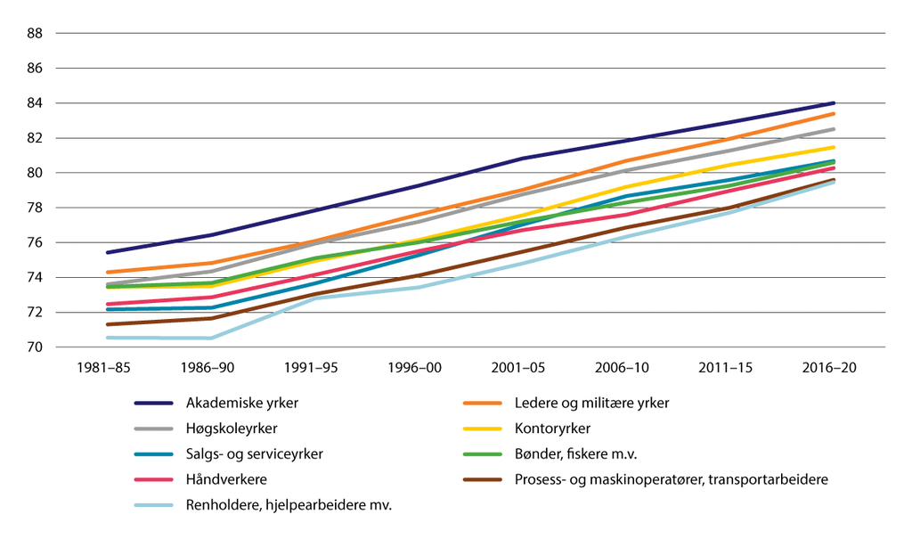

Forventet levealder ved fødselen i ni yrkesfelt for menn. År. Femårsperioder 1981–2020. Kilde: Texmon (2022).

## Levealder og yrke - kvinner

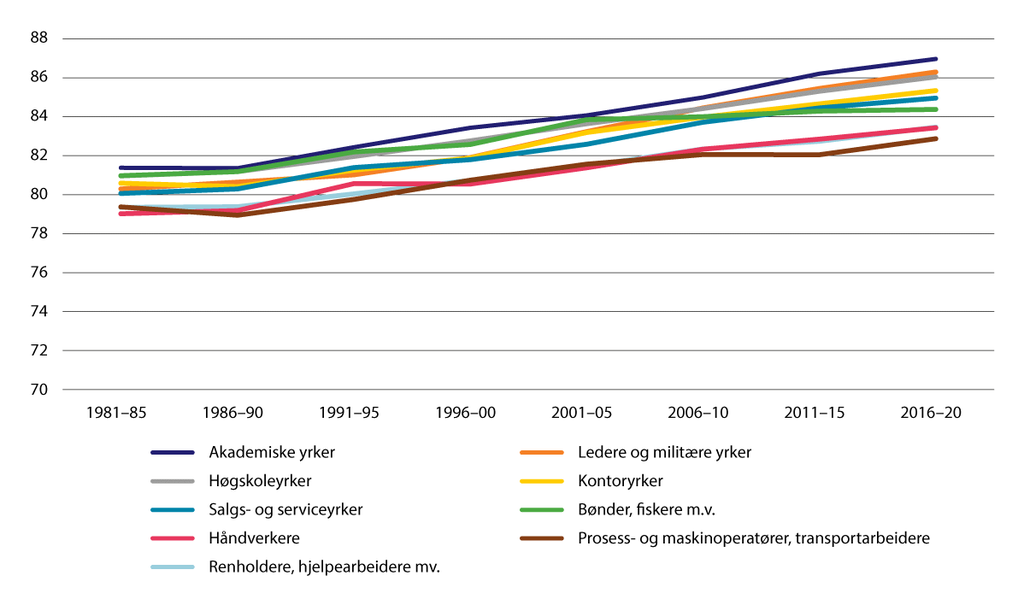

Forventet levealder ved fødselen i ni yrkesfelt for kvinner År. Femårsperioder 1981–2020. Kilde: Texmon (2022).